# Risk Factor Analysis

## Outcome Variable

**Outcome Variable:** sstunted

## Predictor Variables

**Intervention Variable:** feducyrs

**Adjustment Set:**

unadjusted

## Stratifying Variables

The analysis was stratified on these variable(s):

- agecat
- studyid
- country

## Data Summary

| agecat | studyid | country | A | n | nA | nAY0 | nAY1 |
| --- | --- | --- | --- | --- | --- | --- | --- |
| Birth | ki0047075b-MAL-ED | BANGLADESH | Q4 | 144 | 52 | 49 | 3 |
| Birth | ki0047075b-MAL-ED | BANGLADESH | Q1 | 144 | 29 | 28 | 1 |
| Birth | ki0047075b-MAL-ED | BANGLADESH | Q2 | 144 | 9 | 9 | 0 |
| Birth | ki0047075b-MAL-ED | BANGLADESH | Q3 | 144 | 54 | 52 | 2 |
| Birth | ki0047075b-MAL-ED | INDIA | Q4 | 123 | 38 | 38 | 0 |
| Birth | ki0047075b-MAL-ED | INDIA | Q1 | 123 | 21 | 20 | 1 |
| Birth | ki0047075b-MAL-ED | INDIA | Q2 | 123 | 37 | 36 | 1 |
| Birth | ki0047075b-MAL-ED | INDIA | Q3 | 123 | 27 | 26 | 1 |
| Birth | ki0047075b-MAL-ED | NEPAL | Q4 | 67 | 27 | 27 | 0 |
| Birth | ki0047075b-MAL-ED | NEPAL | Q1 | 67 | 18 | 17 | 1 |
| Birth | ki0047075b-MAL-ED | NEPAL | Q2 | 67 | 17 | 14 | 3 |
| Birth | ki0047075b-MAL-ED | NEPAL | Q3 | 67 | 5 | 5 | 0 |
| Birth | ki0047075b-MAL-ED | PERU | Q4 | 236 | 116 | 113 | 3 |
| Birth | ki0047075b-MAL-ED | PERU | Q1 | 236 | 47 | 45 | 2 |
| Birth | ki0047075b-MAL-ED | PERU | Q2 | 236 | 62 | 61 | 1 |
| Birth | ki0047075b-MAL-ED | PERU | Q3 | 236 | 11 | 11 | 0 |
| Birth | ki0047075b-MAL-ED | SOUTH AFRICA | Q4 | 91 | 35 | 35 | 0 |
| Birth | ki0047075b-MAL-ED | SOUTH AFRICA | Q1 | 91 | 15 | 15 | 0 |
| Birth | ki0047075b-MAL-ED | SOUTH AFRICA | Q2 | 91 | 22 | 22 | 0 |
| Birth | ki0047075b-MAL-ED | SOUTH AFRICA | Q3 | 91 | 19 | 19 | 0 |
| Birth | ki0047075b-MAL-ED | TANZANIA, UNITED REPUBLIC OF | Q4 | 101 | 3 | 3 | 0 |
| Birth | ki0047075b-MAL-ED | TANZANIA, UNITED REPUBLIC OF | Q1 | 101 | 20 | 19 | 1 |
| Birth | ki0047075b-MAL-ED | TANZANIA, UNITED REPUBLIC OF | Q2 | 101 | 16 | 14 | 2 |
| Birth | ki0047075b-MAL-ED | TANZANIA, UNITED REPUBLIC OF | Q3 | 101 | 62 | 59 | 3 |
| Birth | ki1017093c-NIH-Crypto | BANGLADESH | Q4 | 27 | 5 | 5 | 0 |
| Birth | ki1017093c-NIH-Crypto | BANGLADESH | Q1 | 27 | 4 | 4 | 0 |
| Birth | ki1017093c-NIH-Crypto | BANGLADESH | Q2 | 27 | 11 | 11 | 0 |
| Birth | ki1017093c-NIH-Crypto | BANGLADESH | Q3 | 27 | 7 | 6 | 1 |
| Birth | ki1126311-ZVITAMBO | ZIMBABWE | Q4 | 13460 | 11504 | 11154 | 350 |
| Birth | ki1126311-ZVITAMBO | ZIMBABWE | Q1 | 13460 | 82 | 77 | 5 |

[output cut: 386 more lines]

The following strata were considered:

- agecat: 12 months, studyid: ki0047075b-MAL-ED, country: BANGLADESH
- agecat: 12 months, studyid: ki0047075b-MAL-ED, country: INDIA
- agecat: 12 months, studyid: ki0047075b-MAL-ED, country: NEPAL
- agecat: 12 months, studyid: ki0047075b-MAL-ED, country: PERU
- agecat: 12 months, studyid: ki0047075b-MAL-ED, country: SOUTH AFRICA
- agecat: 12 months, studyid: ki0047075b-MAL-ED, country: TANZANIA, UNITED REPUBLIC OF
- agecat: 12 months, studyid: ki1000304b-SAS-FoodSuppl, country: INDIA
- agecat: 12 months, studyid: ki1017093b-PROVIDE, country: BANGLADESH
- agecat: 12 months, studyid: ki1017093c-NIH-Crypto, country: BANGLADESH
- agecat: 12 months, studyid: ki1066203-TanzaniaChild2, country: TANZANIA, UNITED REPUBLIC OF
- agecat: 12 months, studyid: ki1113344-GMS-Nepal, country: NEPAL
- agecat: 12 months, studyid: ki1126311-ZVITAMBO, country: ZIMBABWE
- agecat: 12 months, studyid: ki1135781-COHORTS, country: GUATEMALA
- agecat: 12 months, studyid: ki1135781-COHORTS, country: INDIA
- agecat: 12 months, studyid: ki1135781-COHORTS, country: PHILIPPINES
- agecat: 12 months, studyid: ki1148112-LCNI-5, country: MALAWI
- agecat: 18 months, studyid: ki0047075b-MAL-ED, country: BANGLADESH
- agecat: 18 months, studyid: ki0047075b-MAL-ED, country: INDIA
- agecat: 18 months, studyid: ki0047075b-MAL-ED, country: NEPAL
- agecat: 18 months, studyid: ki0047075b-MAL-ED, country: PERU
- agecat: 18 months, studyid: ki0047075b-MAL-ED, country: SOUTH AFRICA
- agecat: 18 months, studyid: ki0047075b-MAL-ED, country: TANZANIA, UNITED REPUBLIC OF
- agecat: 18 months, studyid: ki1000304b-SAS-FoodSuppl, country: INDIA
- agecat: 18 months, studyid: ki1017093b-PROVIDE, country: BANGLADESH
- agecat: 18 months, studyid: ki1017093c-NIH-Crypto, country: BANGLADESH
- agecat: 18 months, studyid: ki1066203-TanzaniaChild2, country: TANZANIA, UNITED REPUBLIC OF
- agecat: 18 months, studyid: ki1113344-GMS-Nepal, country: NEPAL
- agecat: 18 months, studyid: ki1126311-ZVITAMBO, country: ZIMBABWE
- agecat: 18 months, studyid: ki1135781-COHORTS, country: GUATEMALA
- agecat: 18 months, studyid: ki1135781-COHORTS, country: PHILIPPINES
- agecat: 18 months, studyid: ki1148112-LCNI-5, country: MALAWI
- agecat: 24 months, studyid: ki0047075b-MAL-ED, country: BANGLADESH
- agecat: 24 months, studyid: ki0047075b-MAL-ED, country: INDIA
- agecat: 24 months, studyid: ki0047075b-MAL-ED, country: NEPAL
- agecat: 24 months, studyid: ki0047075b-MAL-ED, country: PERU
- agecat: 24 months, studyid: ki0047075b-MAL-ED, country: SOUTH AFRICA
- agecat: 24 months, studyid: ki0047075b-MAL-ED, country: TANZANIA, UNITED REPUBLIC OF
- agecat: 24 months, studyid: ki1017093b-PROVIDE, country: BANGLADESH
- agecat: 24 months, studyid: ki1017093c-NIH-Crypto, country: BANGLADESH
- agecat: 24 months, studyid: ki1066203-TanzaniaChild2, country: TANZANIA, UNITED REPUBLIC OF
- agecat: 24 months, studyid: ki1113344-GMS-Nepal, country: NEPAL
- agecat: 24 months, studyid: ki1126311-ZVITAMBO, country: ZIMBABWE
- agecat: 24 months, studyid: ki1135781-COHORTS, country: GUATEMALA
- agecat: 24 months, studyid: ki1135781-COHORTS, country: INDIA
- agecat: 24 months, studyid: ki1135781-COHORTS, country: PHILIPPINES
- agecat: 24 months, studyid: ki1148112-LCNI-5, country: MALAWI
- agecat: 3 months, studyid: ki0047075b-MAL-ED, country: BANGLADESH
- agecat: 3 months, studyid: ki0047075b-MAL-ED, country: INDIA
- agecat: 3 months, studyid: ki0047075b-MAL-ED, country: NEPAL
- agecat: 3 months, studyid: ki0047075b-MAL-ED, country: PERU
- agecat: 3 months, studyid: ki0047075b-MAL-ED, country: SOUTH AFRICA
- agecat: 3 months, studyid: ki0047075b-MAL-ED, country: TANZANIA, UNITED REPUBLIC OF
- agecat: 3 months, studyid: ki1000304b-SAS-FoodSuppl, country: INDIA
- agecat: 3 months, studyid: ki1017093b-PROVIDE, country: BANGLADESH
- agecat: 3 months, studyid: ki1017093c-NIH-Crypto, country: BANGLADESH
- agecat: 3 months, studyid: ki1066203-TanzaniaChild2, country: TANZANIA, UNITED REPUBLIC OF
- agecat: 3 months, studyid: ki1113344-GMS-Nepal, country: NEPAL
- agecat: 3 months, studyid: ki1126311-ZVITAMBO, country: ZIMBABWE
- agecat: 3 months, studyid: ki1135781-COHORTS, country: GUATEMALA
- agecat: 3 months, studyid: ki1135781-COHORTS, country: INDIA
- agecat: 3 months, studyid: ki1135781-COHORTS, country: PHILIPPINES
- agecat: 6 months, studyid: ki0047075b-MAL-ED, country: BANGLADESH
- agecat: 6 months, studyid: ki0047075b-MAL-ED, country: INDIA
- agecat: 6 months, studyid: ki0047075b-MAL-ED, country: NEPAL
- agecat: 6 months, studyid: ki0047075b-MAL-ED, country: PERU
- agecat: 6 months, studyid: ki0047075b-MAL-ED, country: SOUTH AFRICA
- agecat: 6 months, studyid: ki0047075b-MAL-ED, country: TANZANIA, UNITED REPUBLIC OF
- agecat: 6 months, studyid: ki1000304b-SAS-FoodSuppl, country: INDIA
- agecat: 6 months, studyid: ki1017093b-PROVIDE, country: BANGLADESH
- agecat: 6 months, studyid: ki1017093c-NIH-Crypto, country: BANGLADESH
- agecat: 6 months, studyid: ki1066203-TanzaniaChild2, country: TANZANIA, UNITED REPUBLIC OF
- agecat: 6 months, studyid: ki1113344-GMS-Nepal, country: NEPAL
- agecat: 6 months, studyid: ki1126311-ZVITAMBO, country: ZIMBABWE
- agecat: 6 months, studyid: ki1135781-COHORTS, country: GUATEMALA
- agecat: 6 months, studyid: ki1135781-COHORTS, country: INDIA
- agecat: 6 months, studyid: ki1135781-COHORTS, country: PHILIPPINES
- agecat: 6 months, studyid: ki1148112-LCNI-5, country: MALAWI
- agecat: 9 months, studyid: ki0047075b-MAL-ED, country: BANGLADESH
- agecat: 9 months, studyid: ki0047075b-MAL-ED, country: INDIA
- agecat: 9 months, studyid: ki0047075b-MAL-ED, country: NEPAL
- agecat: 9 months, studyid: ki0047075b-MAL-ED, country: PERU
- agecat: 9 months, studyid: ki0047075b-MAL-ED, country: SOUTH AFRICA
- agecat: 9 months, studyid: ki0047075b-MAL-ED, country: TANZANIA, UNITED REPUBLIC OF
- agecat: 9 months, studyid: ki1000304b-SAS-FoodSuppl, country: INDIA
- agecat: 9 months, studyid: ki1017093b-PROVIDE, country: BANGLADESH
- agecat: 9 months, studyid: ki1017093c-NIH-Crypto, country: BANGLADESH
- agecat: 9 months, studyid: ki1066203-TanzaniaChild2, country: TANZANIA, UNITED REPUBLIC OF
- agecat: 9 months, studyid: ki1113344-GMS-Nepal, country: NEPAL
- agecat: 9 months, studyid: ki1126311-ZVITAMBO, country: ZIMBABWE
- agecat: 9 months, studyid: ki1135781-COHORTS, country: GUATEMALA
- agecat: 9 months, studyid: ki1135781-COHORTS, country: INDIA
- agecat: 9 months, studyid: ki1135781-COHORTS, country: PHILIPPINES
- agecat: 9 months, studyid: ki1148112-LCNI-5, country: MALAWI
- agecat: Birth, studyid: ki0047075b-MAL-ED, country: BANGLADESH
- agecat: Birth, studyid: ki0047075b-MAL-ED, country: INDIA
- agecat: Birth, studyid: ki0047075b-MAL-ED, country: NEPAL
- agecat: Birth, studyid: ki0047075b-MAL-ED, country: PERU
- agecat: Birth, studyid: ki0047075b-MAL-ED, country: SOUTH AFRICA
- agecat: Birth, studyid: ki0047075b-MAL-ED, country: TANZANIA, UNITED REPUBLIC OF
- agecat: Birth, studyid: ki1017093c-NIH-Crypto, country: BANGLADESH
- agecat: Birth, studyid: ki1126311-ZVITAMBO, country: ZIMBABWE
- agecat: Birth, studyid: ki1135781-COHORTS, country: GUATEMALA
- agecat: Birth, studyid: ki1135781-COHORTS, country: INDIA
- agecat: Birth, studyid: ki1135781-COHORTS, country: PHILIPPINES

### Dropped Strata

Some strata were dropped due to rare outcomes:

- agecat: Birth, studyid: ki0047075b-MAL-ED, country: BANGLADESH
- agecat: Birth, studyid: ki0047075b-MAL-ED, country: INDIA
- agecat: Birth, studyid: ki0047075b-MAL-ED, country: NEPAL
- agecat: Birth, studyid: ki0047075b-MAL-ED, country: PERU
- agecat: Birth, studyid: ki0047075b-MAL-ED, country: SOUTH AFRICA
- agecat: Birth, studyid: ki0047075b-MAL-ED, country: TANZANIA, UNITED REPUBLIC OF
- agecat: Birth, studyid: ki1017093c-NIH-Crypto, country: BANGLADESH
- agecat: Birth, studyid: ki1126311-ZVITAMBO, country: ZIMBABWE
- agecat: Birth, studyid: ki1135781-COHORTS, country: GUATEMALA
- agecat: Birth, studyid: ki1135781-COHORTS, country: INDIA
- agecat: Birth, studyid: ki1135781-COHORTS, country: PHILIPPINES
- agecat: 3 months, studyid: ki0047075b-MAL-ED, country: BANGLADESH
- agecat: 3 months, studyid: ki0047075b-MAL-ED, country: INDIA
- agecat: 3 months, studyid: ki0047075b-MAL-ED, country: NEPAL
- agecat: 3 months, studyid: ki0047075b-MAL-ED, country: PERU
- agecat: 3 months, studyid: ki0047075b-MAL-ED, country: SOUTH AFRICA
- agecat: 3 months, studyid: ki0047075b-MAL-ED, country: TANZANIA, UNITED REPUBLIC OF
- agecat: 3 months, studyid: ki1000304b-SAS-FoodSuppl, country: INDIA
- agecat: 3 months, studyid: ki1017093b-PROVIDE, country: BANGLADESH
- agecat: 3 months, studyid: ki1066203-TanzaniaChild2, country: TANZANIA, UNITED REPUBLIC OF
- agecat: 3 months, studyid: ki1113344-GMS-Nepal, country: NEPAL
- agecat: 3 months, studyid: ki1126311-ZVITAMBO, country: ZIMBABWE
- agecat: 3 months, studyid: ki1135781-COHORTS, country: GUATEMALA
- agecat: 3 months, studyid: ki1135781-COHORTS, country: INDIA
- agecat: 6 months, studyid: ki0047075b-MAL-ED, country: BANGLADESH
- agecat: 6 months, studyid: ki0047075b-MAL-ED, country: INDIA
- agecat: 6 months, studyid: ki0047075b-MAL-ED, country: NEPAL
- agecat: 6 months, studyid: ki0047075b-MAL-ED, country: PERU
- agecat: 6 months, studyid: ki0047075b-MAL-ED, country: SOUTH AFRICA
- agecat: 6 months, studyid: ki0047075b-MAL-ED, country: TANZANIA, UNITED REPUBLIC OF
- agecat: 6 months, studyid: ki1000304b-SAS-FoodSuppl, country: INDIA
- agecat: 6 months, studyid: ki1017093b-PROVIDE, country: BANGLADESH
- agecat: 6 months, studyid: ki1017093c-NIH-Crypto, country: BANGLADESH
- agecat: 6 months, studyid: ki1066203-TanzaniaChild2, country: TANZANIA, UNITED REPUBLIC OF
- agecat: 6 months, studyid: ki1113344-GMS-Nepal, country: NEPAL
- agecat: 6 months, studyid: ki1126311-ZVITAMBO, country: ZIMBABWE
- agecat: 6 months, studyid: ki1135781-COHORTS, country: GUATEMALA
- agecat: 6 months, studyid: ki1148112-LCNI-5, country: MALAWI
- agecat: 9 months, studyid: ki0047075b-MAL-ED, country: BANGLADESH
- agecat: 9 months, studyid: ki0047075b-MAL-ED, country: INDIA
- agecat: 9 months, studyid: ki0047075b-MAL-ED, country: NEPAL
- agecat: 9 months, studyid: ki0047075b-MAL-ED, country: PERU
- agecat: 9 months, studyid: ki0047075b-MAL-ED, country: SOUTH AFRICA
- agecat: 9 months, studyid: ki0047075b-MAL-ED, country: TANZANIA, UNITED REPUBLIC OF
- agecat: 9 months, studyid: ki1000304b-SAS-FoodSuppl, country: INDIA
- agecat: 9 months, studyid: ki1017093b-PROVIDE, country: BANGLADESH
- agecat: 9 months, studyid: ki1017093c-NIH-Crypto, country: BANGLADESH
- agecat: 9 months, studyid: ki1066203-TanzaniaChild2, country: TANZANIA, UNITED REPUBLIC OF
- agecat: 9 months, studyid: ki1113344-GMS-Nepal, country: NEPAL
- agecat: 9 months, studyid: ki1126311-ZVITAMBO, country: ZIMBABWE
- agecat: 9 months, studyid: ki1135781-COHORTS, country: GUATEMALA
- agecat: 9 months, studyid: ki1148112-LCNI-5, country: MALAWI
- agecat: 12 months, studyid: ki0047075b-MAL-ED, country: BANGLADESH
- agecat: 12 months, studyid: ki0047075b-MAL-ED, country: INDIA
- agecat: 12 months, studyid: ki0047075b-MAL-ED, country: NEPAL
- agecat: 12 months, studyid: ki0047075b-MAL-ED, country: PERU
- agecat: 12 months, studyid: ki0047075b-MAL-ED, country: SOUTH AFRICA
- agecat: 12 months, studyid: ki0047075b-MAL-ED, country: TANZANIA, UNITED REPUBLIC OF
- agecat: 12 months, studyid: ki1000304b-SAS-FoodSuppl, country: INDIA
- agecat: 12 months, studyid: ki1017093b-PROVIDE, country: BANGLADESH
- agecat: 12 months, studyid: ki1066203-TanzaniaChild2, country: TANZANIA, UNITED REPUBLIC OF
- agecat: 12 months, studyid: ki1113344-GMS-Nepal, country: NEPAL
- agecat: 12 months, studyid: ki1135781-COHORTS, country: GUATEMALA
- agecat: 12 months, studyid: ki1148112-LCNI-5, country: MALAWI
- agecat: 18 months, studyid: ki0047075b-MAL-ED, country: BANGLADESH
- agecat: 18 months, studyid: ki0047075b-MAL-ED, country: INDIA
- agecat: 18 months, studyid: ki0047075b-MAL-ED, country: NEPAL
- agecat: 18 months, studyid: ki0047075b-MAL-ED, country: PERU
- agecat: 18 months, studyid: ki0047075b-MAL-ED, country: SOUTH AFRICA
- agecat: 18 months, studyid: ki0047075b-MAL-ED, country: TANZANIA, UNITED REPUBLIC OF
- agecat: 18 months, studyid: ki1000304b-SAS-FoodSuppl, country: INDIA
- agecat: 18 months, studyid: ki1017093b-PROVIDE, country: BANGLADESH
- agecat: 18 months, studyid: ki1066203-TanzaniaChild2, country: TANZANIA, UNITED REPUBLIC OF
- agecat: 18 months, studyid: ki1126311-ZVITAMBO, country: ZIMBABWE
- agecat: 18 months, studyid: ki1135781-COHORTS, country: GUATEMALA
- agecat: 24 months, studyid: ki0047075b-MAL-ED, country: BANGLADESH
- agecat: 24 months, studyid: ki0047075b-MAL-ED, country: INDIA
- agecat: 24 months, studyid: ki0047075b-MAL-ED, country: NEPAL
- agecat: 24 months, studyid: ki0047075b-MAL-ED, country: PERU
- agecat: 24 months, studyid: ki0047075b-MAL-ED, country: SOUTH AFRICA
- agecat: 24 months, studyid: ki0047075b-MAL-ED, country: TANZANIA, UNITED REPUBLIC OF
- agecat: 24 months, studyid: ki1017093b-PROVIDE, country: BANGLADESH
- agecat: 24 months, studyid: ki1066203-TanzaniaChild2, country: TANZANIA, UNITED REPUBLIC OF
- agecat: 24 months, studyid: ki1126311-ZVITAMBO, country: ZIMBABWE
- agecat: 24 months, studyid: ki1135781-COHORTS, country: GUATEMALA
- agecat: 24 months, studyid: ki1148112-LCNI-5, country: MALAWI

## Methods Detail

We’re interested in the causal parameters $E[Y_a]$ for all values of $a \in \mathcal{A}$. These parameters represent the mean outcome if, possibly contrary to fact, we intervened to set all units to have $A=a$. Under the randomization and positivity assumptions, these are identified by the statistical parameters $\psi_a=E_W[E_{Y|A,W}(Y|A=a,W)]$. In addition, we’re interested in the mean of $Y$, $E[Y]$ under no intervention (the observed mean). We will estimate these parameters by using SuperLearner to fit the relevant likelihood factors – $E_{Y|A,W}(Y|A=a,W)$ and $p(A=a|W)$, and then updating our likelihood fit using a joint TMLE.

For unadjusted analyses ($W=\{\}$), initial likelihoods were estimated using Lrnr_glm to estimate the simple $E(Y|A)$ and Lrnr_mean to estimate $p(A)$. For adjusted analyses, a small library containing Lrnr_glmnet, Lrnr_xgboost, and Lrnr_mean was used.

Having estimated these parameters, we will then use the delta method to estimate relative risks and attributable risks relative to a prespecified baseline level of $A$.

# Results Detail

## Results Plots

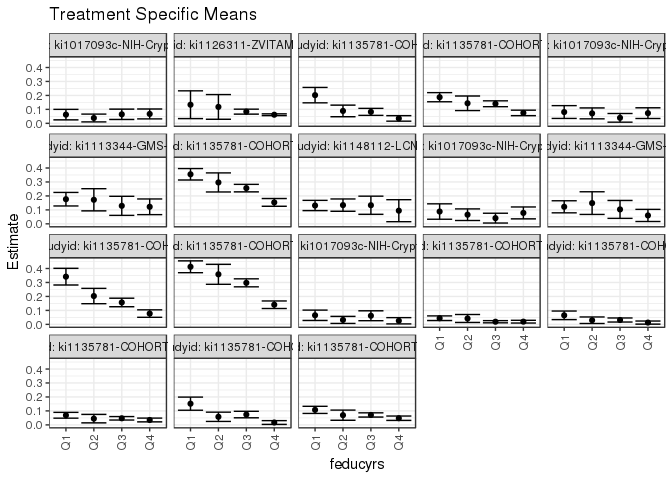

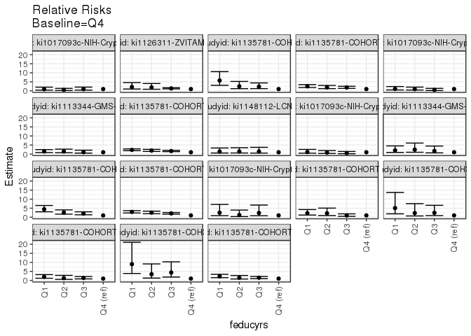

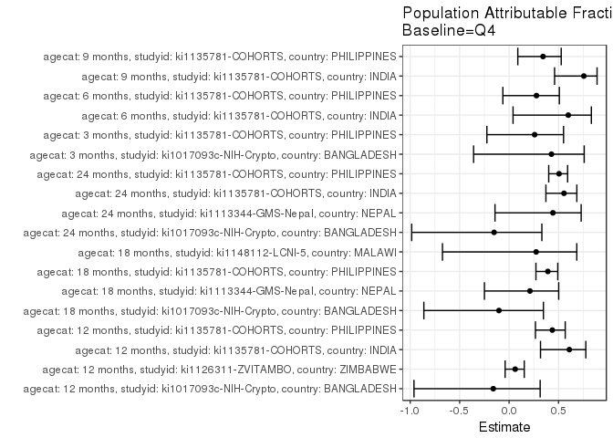

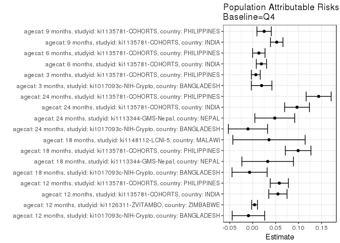

## Results Table

### Parameter: TSM

| agecat | studyid | country | intervention_level | baseline_level | estimate | ci_lower | ci_upper |
| --- | --- | --- | --- | --- | --- | --- | --- |
| 3 months | ki1017093c-NIH-Crypto | BANGLADESH | Q4 | NA | 0.0259067 | 0.0034796 | 0.0483339 |
| 3 months | ki1017093c-NIH-Crypto | BANGLADESH | Q1 | NA | 0.0650888 | 0.0278718 | 0.1023058 |
| 3 months | ki1017093c-NIH-Crypto | BANGLADESH | Q2 | NA | 0.0319149 | 0.0067717 | 0.0570581 |
| 3 months | ki1017093c-NIH-Crypto | BANGLADESH | Q3 | NA | 0.0617978 | 0.0264004 | 0.0971951 |
| 3 months | ki1135781-COHORTS | PHILIPPINES | Q4 | NA | 0.0193798 | 0.0096662 | 0.0290935 |
| 3 months | ki1135781-COHORTS | PHILIPPINES | Q1 | NA | 0.0439932 | 0.0274562 | 0.0605303 |
| 3 months | ki1135781-COHORTS | PHILIPPINES | Q2 | NA | 0.0421053 | 0.0135439 | 0.0706666 |
| 3 months | ki1135781-COHORTS | PHILIPPINES | Q3 | NA | 0.0189329 | 0.0110953 | 0.0267705 |
| 6 months | ki1135781-COHORTS | INDIA | Q4 | NA | 0.0127551 | 0.0016425 | 0.0238677 |
| 6 months | ki1135781-COHORTS | INDIA | Q1 | NA | 0.0647773 | 0.0340712 | 0.0954835 |
| 6 months | ki1135781-COHORTS | INDIA | Q2 | NA | 0.0295567 | 0.0062505 | 0.0528628 |
| 6 months | ki1135781-COHORTS | INDIA | Q3 | NA | 0.0313076 | 0.0166547 | 0.0459604 |
| 6 months | ki1135781-COHORTS | PHILIPPINES | Q4 | NA | 0.0349650 | 0.0214981 | 0.0484320 |
| 6 months | ki1135781-COHORTS | PHILIPPINES | Q1 | NA | 0.0687831 | 0.0479474 | 0.0896187 |
| 6 months | ki1135781-COHORTS | PHILIPPINES | Q2 | NA | 0.0446927 | 0.0144169 | 0.0749686 |
| 6 months | ki1135781-COHORTS | PHILIPPINES | Q3 | NA | 0.0471442 | 0.0346337 | 0.0596546 |
| 9 months | ki1135781-COHORTS | INDIA | Q4 | NA | 0.0169014 | 0.0034871 | 0.0303157 |
| 9 months | ki1135781-COHORTS | INDIA | Q1 | NA | 0.1517857 | 0.1047784 | 0.1987930 |
| 9 months | ki1135781-COHORTS | INDIA | Q2 | NA | 0.0578947 | 0.0246737 | 0.0911158 |
| 9 months | ki1135781-COHORTS | INDIA | Q3 | NA | 0.0739220 | 0.0506750 | 0.0971690 |
| 9 months | ki1135781-COHORTS | PHILIPPINES | Q4 | NA | 0.0476190 | 0.0319955 | 0.0632426 |
| 9 months | ki1135781-COHORTS | PHILIPPINES | Q1 | NA | 0.1075838 | 0.0820745 | 0.1330931 |
| 9 months | ki1135781-COHORTS | PHILIPPINES | Q2 | NA | 0.0695187 | 0.0330587 | 0.1059787 |
| 9 months | ki1135781-COHORTS | PHILIPPINES | Q3 | NA | 0.0711030 | 0.0558920 | 0.0863140 |
| 12 months | ki1017093c-NIH-Crypto | BANGLADESH | Q4 | NA | 0.0673575 | 0.0319718 | 0.1027432 |
| 12 months | ki1017093c-NIH-Crypto | BANGLADESH | Q1 | NA | 0.0625000 | 0.0249663 | 0.1000337 |
| 12 months | ki1017093c-NIH-Crypto | BANGLADESH | Q2 | NA | 0.0382514 | 0.0104424 | 0.0660603 |
| 12 months | ki1017093c-NIH-Crypto | BANGLADESH | Q3 | NA | 0.0647059 | 0.0276994 | 0.1017123 |
| 12 months | ki1126311-ZVITAMBO | ZIMBABWE | Q4 | NA | 0.0617530 | 0.0554038 | 0.0681022 |
| 12 months | ki1126311-ZVITAMBO | ZIMBABWE | Q1 | NA | 0.1333333 | 0.0340056 | 0.2326610 |
| 12 months | ki1126311-ZVITAMBO | ZIMBABWE | Q2 | NA | 0.1176471 | 0.0292154 | 0.2060787 |
| 12 months | ki1126311-ZVITAMBO | ZIMBABWE | Q3 | NA | 0.0837809 | 0.0659826 | 0.1015792 |
| 12 months | ki1135781-COHORTS | INDIA | Q4 | NA | 0.0352941 | 0.0156722 | 0.0549160 |
| 12 months | ki1135781-COHORTS | INDIA | Q1 | NA | 0.2019704 | 0.1467199 | 0.2572210 |
| 12 months | ki1135781-COHORTS | INDIA | Q2 | NA | 0.0888889 | 0.0472974 | 0.1304804 |
| 12 months | ki1135781-COHORTS | INDIA | Q3 | NA | 0.0822511 | 0.0571875 | 0.1073147 |
| 12 months | ki1135781-COHORTS | PHILIPPINES | Q4 | NA | 0.0747801 | 0.0550349 | 0.0945252 |
| 12 months | ki1135781-COHORTS | PHILIPPINES | Q1 | NA | 0.1872727 | 0.1546616 | 0.2198838 |
| 12 months | ki1135781-COHORTS | PHILIPPINES | Q2 | NA | 0.1436782 | 0.0915496 | 0.1958068 |
| 12 months | ki1135781-COHORTS | PHILIPPINES | Q3 | NA | 0.1402498 | 0.1191514 | 0.1613481 |
| 18 months | ki1017093c-NIH-Crypto | BANGLADESH | Q4 | NA | 0.0730337 | 0.0347799 | 0.1112875 |
| 18 months | ki1017093c-NIH-Crypto | BANGLADESH | Q1 | NA | 0.0808824 | 0.0350224 | 0.1267423 |
| 18 months | ki1017093c-NIH-Crypto | BANGLADESH | Q2 | NA | 0.0714286 | 0.0324541 | 0.1104030 |
| 18 months | ki1017093c-NIH-Crypto | BANGLADESH | Q3 | NA | 0.0394737 | 0.0084940 | 0.0704534 |
| 18 months | ki1113344-GMS-Nepal | NEPAL | Q4 | NA | 0.1221374 | 0.0660137 | 0.1782611 |
| 18 months | ki1113344-GMS-Nepal | NEPAL | Q1 | NA | 0.1764706 | 0.1279941 | 0.2249471 |
| 18 months | ki1113344-GMS-Nepal | NEPAL | Q2 | NA | 0.1724138 | 0.0929669 | 0.2518607 |
| 18 months | ki1113344-GMS-Nepal | NEPAL | Q3 | NA | 0.1290323 | 0.0608372 | 0.1972273 |
| 18 months | ki1135781-COHORTS | PHILIPPINES | Q4 | NA | 0.1536098 | 0.1259057 | 0.1813140 |
| 18 months | ki1135781-COHORTS | PHILIPPINES | Q1 | NA | 0.3549618 | 0.3139831 | 0.3959405 |
| 18 months | ki1135781-COHORTS | PHILIPPINES | Q2 | NA | 0.2965116 | 0.2282423 | 0.3647809 |
| 18 months | ki1135781-COHORTS | PHILIPPINES | Q3 | NA | 0.2559524 | 0.2290066 | 0.2828981 |
| 18 months | ki1148112-LCNI-5 | MALAWI | Q4 | NA | 0.0943396 | 0.0155909 | 0.1730883 |
| 18 months | ki1148112-LCNI-5 | MALAWI | Q1 | NA | 0.1314985 | 0.0948443 | 0.1681526 |
| 18 months | ki1148112-LCNI-5 | MALAWI | Q2 | NA | 0.1341991 | 0.0902116 | 0.1781867 |
| 18 months | ki1148112-LCNI-5 | MALAWI | Q3 | NA | 0.1333333 | 0.0682676 | 0.1983991 |
| 24 months | ki1017093c-NIH-Crypto | BANGLADESH | Q4 | NA | 0.0784314 | 0.0357897 | 0.1210730 |
| 24 months | ki1017093c-NIH-Crypto | BANGLADESH | Q1 | NA | 0.0882353 | 0.0331376 | 0.1433330 |
| 24 months | ki1017093c-NIH-Crypto | BANGLADESH | Q2 | NA | 0.0656934 | 0.0241678 | 0.1072191 |
| 24 months | ki1017093c-NIH-Crypto | BANGLADESH | Q3 | NA | 0.0409836 | 0.0057701 | 0.0761971 |
| 24 months | ki1113344-GMS-Nepal | NEPAL | Q4 | NA | 0.0603448 | 0.0169678 | 0.1037219 |
| 24 months | ki1113344-GMS-Nepal | NEPAL | Q1 | NA | 0.1221719 | 0.0789525 | 0.1653914 |
| 24 months | ki1113344-GMS-Nepal | NEPAL | Q2 | NA | 0.1486486 | 0.0675145 | 0.2297828 |
| 24 months | ki1113344-GMS-Nepal | NEPAL | Q3 | NA | 0.1034483 | 0.0393901 | 0.1675064 |
| 24 months | ki1135781-COHORTS | INDIA | Q4 | NA | 0.0773196 | 0.0507332 | 0.1039060 |
| 24 months | ki1135781-COHORTS | INDIA | Q1 | NA | 0.3415638 | 0.2819159 | 0.4012117 |
| 24 months | ki1135781-COHORTS | INDIA | Q2 | NA | 0.2028986 | 0.1480940 | 0.2577031 |
| 24 months | ki1135781-COHORTS | INDIA | Q3 | NA | 0.1568266 | 0.1262017 | 0.1874514 |
| 24 months | ki1135781-COHORTS | PHILIPPINES | Q4 | NA | 0.1406250 | 0.1136864 | 0.1675636 |
| 24 months | ki1135781-COHORTS | PHILIPPINES | Q1 | NA | 0.4123314 | 0.3699722 | 0.4546906 |
| 24 months | ki1135781-COHORTS | PHILIPPINES | Q2 | NA | 0.3583815 | 0.2869105 | 0.4298525 |
| 24 months | ki1135781-COHORTS | PHILIPPINES | Q3 | NA | 0.2973523 | 0.2687573 | 0.3259474 |

### Parameter: E(Y)

| agecat | studyid | country | intervention_level | baseline_level | estimate | ci_lower | ci_upper |
| --- | --- | --- | --- | --- | --- | --- | --- |
| 3 months | ki1017093c-NIH-Crypto | BANGLADESH | NA | NA | 0.0453297 | 0.0440635 | 0.0465959 |
| 3 months | ki1135781-COHORTS | PHILIPPINES | NA | NA | 0.0261318 | 0.0257157 | 0.0265478 |
| 6 months | ki1135781-COHORTS | INDIA | NA | NA | 0.0317690 | 0.0308603 | 0.0326776 |
| 6 months | ki1135781-COHORTS | PHILIPPINES | NA | NA | 0.0483619 | 0.0478976 | 0.0488263 |
| 9 months | ki1135781-COHORTS | INDIA | NA | NA | 0.0692675 | 0.0667825 | 0.0717525 |
| 9 months | ki1135781-COHORTS | PHILIPPINES | NA | NA | 0.0725146 | 0.0716973 | 0.0733320 |
| 12 months | ki1017093c-NIH-Crypto | BANGLADESH | NA | NA | 0.0580737 | 0.0571989 | 0.0589484 |
| 12 months | ki1126311-ZVITAMBO | ZIMBABWE | NA | NA | 0.0658116 | 0.0655552 | 0.0660680 |
| 12 months | ki1135781-COHORTS | INDIA | NA | NA | 0.0902954 | 0.0871600 | 0.0934307 |
| 12 months | ki1135781-COHORTS | PHILIPPINES | NA | NA | 0.1328157 | 0.1312122 | 0.1344192 |
| 18 months | ki1017093c-NIH-Crypto | BANGLADESH | NA | NA | 0.0662461 | 0.0650446 | 0.0674475 |
| 18 months | ki1113344-GMS-Nepal | NEPAL | NA | NA | 0.1548270 | 0.1527426 | 0.1569114 |
| 18 months | ki1135781-COHORTS | PHILIPPINES | NA | NA | 0.2526539 | 0.2497449 | 0.2555630 |
| 18 months | ki1148112-LCNI-5 | MALAWI | NA | NA | 0.1298883 | 0.1291463 | 0.1306302 |
| 24 months | ki1017093c-NIH-Crypto | BANGLADESH | NA | NA | 0.0680934 | 0.0666241 | 0.0695627 |
| 24 months | ki1113344-GMS-Nepal | NEPAL | NA | NA | 0.1084337 | 0.1058449 | 0.1110225 |
| 24 months | ki1135781-COHORTS | INDIA | NA | NA | 0.1739130 | 0.1692477 | 0.1785784 |
| 24 months | ki1135781-COHORTS | PHILIPPINES | NA | NA | 0.2843561 | 0.2803077 | 0.2884045 |

### Parameter: RR

| agecat | studyid | country | intervention_level | baseline_level | estimate | ci_lower | ci_upper |
| --- | --- | --- | --- | --- | --- | --- | --- |
| 3 months | ki1017093c-NIH-Crypto | BANGLADESH | Q4 | Q4 | 1.0000000 | 1.0000000 | 1.000000 |
| 3 months | ki1017093c-NIH-Crypto | BANGLADESH | Q1 | Q4 | 2.5124260 | 0.8902717 | 7.090290 |
| 3 months | ki1017093c-NIH-Crypto | BANGLADESH | Q2 | Q4 | 1.2319149 | 0.3821530 | 3.971222 |
| 3 months | ki1017093c-NIH-Crypto | BANGLADESH | Q3 | Q4 | 2.3853933 | 0.8447894 | 6.735526 |
| 3 months | ki1135781-COHORTS | PHILIPPINES | Q4 | Q4 | 1.0000000 | 1.0000000 | 1.000000 |
| 3 months | ki1135781-COHORTS | PHILIPPINES | Q1 | Q4 | 2.2700507 | 1.2132253 | 4.247464 |
| 3 months | ki1135781-COHORTS | PHILIPPINES | Q2 | Q4 | 2.1726316 | 0.9347441 | 5.049861 |
| 3 months | ki1135781-COHORTS | PHILIPPINES | Q3 | Q4 | 0.9769363 | 0.5099680 | 1.871499 |
| 6 months | ki1135781-COHORTS | INDIA | Q4 | Q4 | 1.0000000 | 1.0000000 | 1.000000 |
| 6 months | ki1135781-COHORTS | INDIA | Q1 | Q4 | 5.0785425 | 1.8836042 | 13.692682 |
| 6 months | ki1135781-COHORTS | INDIA | Q2 | Q4 | 2.3172414 | 0.7155522 | 7.504146 |
| 6 months | ki1135781-COHORTS | INDIA | Q3 | Q4 | 2.4545120 | 0.9129653 | 6.598968 |
| 6 months | ki1135781-COHORTS | PHILIPPINES | Q4 | Q4 | 1.0000000 | 1.0000000 | 1.000000 |
| 6 months | ki1135781-COHORTS | PHILIPPINES | Q1 | Q4 | 1.9671958 | 1.2051521 | 3.211096 |
| 6 months | ki1135781-COHORTS | PHILIPPINES | Q2 | Q4 | 1.2782123 | 0.5863747 | 2.786319 |
| 6 months | ki1135781-COHORTS | PHILIPPINES | Q3 | Q4 | 1.3483228 | 0.8446279 | 2.152397 |
| 9 months | ki1135781-COHORTS | INDIA | Q4 | Q4 | 1.0000000 | 1.0000000 | 1.000000 |
| 9 months | ki1135781-COHORTS | INDIA | Q1 | Q4 | 8.9806541 | 3.8309523 | 21.052767 |
| 9 months | ki1135781-COHORTS | INDIA | Q2 | Q4 | 3.4254383 | 1.2863985 | 9.121301 |
| 9 months | ki1135781-COHORTS | INDIA | Q3 | Q4 | 4.3737163 | 1.8624683 | 10.270991 |
| 9 months | ki1135781-COHORTS | PHILIPPINES | Q4 | Q4 | 1.0000000 | 1.0000000 | 1.000000 |
| 9 months | ki1135781-COHORTS | PHILIPPINES | Q1 | Q4 | 2.2592592 | 1.5071667 | 3.386654 |
| 9 months | ki1135781-COHORTS | PHILIPPINES | Q2 | Q4 | 1.4598930 | 0.7864153 | 2.710130 |
| 9 months | ki1135781-COHORTS | PHILIPPINES | Q3 | Q4 | 1.4931632 | 1.0092618 | 2.209076 |
| 12 months | ki1017093c-NIH-Crypto | BANGLADESH | Q4 | Q4 | 1.0000000 | 1.0000000 | 1.000000 |
| 12 months | ki1017093c-NIH-Crypto | BANGLADESH | Q1 | Q4 | 0.9278846 | 0.4178053 | 2.060696 |
| 12 months | ki1017093c-NIH-Crypto | BANGLADESH | Q2 | Q4 | 0.5678857 | 0.2315902 | 1.392521 |
| 12 months | ki1017093c-NIH-Crypto | BANGLADESH | Q3 | Q4 | 0.9606335 | 0.4418695 | 2.088437 |
| 12 months | ki1126311-ZVITAMBO | ZIMBABWE | Q4 | Q4 | 1.0000000 | 1.0000000 | 1.000000 |
| 12 months | ki1126311-ZVITAMBO | ZIMBABWE | Q1 | Q4 | 2.1591398 | 1.0178478 | 4.580139 |
| 12 months | ki1126311-ZVITAMBO | ZIMBABWE | Q2 | Q4 | 1.9051233 | 0.8921493 | 4.068259 |
| 12 months | ki1126311-ZVITAMBO | ZIMBABWE | Q3 | Q4 | 1.3567097 | 1.0714908 | 1.717851 |
| 12 months | ki1135781-COHORTS | INDIA | Q4 | Q4 | 1.0000000 | 1.0000000 | 1.000000 |
| 12 months | ki1135781-COHORTS | INDIA | Q1 | Q4 | 5.7224959 | 3.0795825 | 10.633571 |
| 12 months | ki1135781-COHORTS | INDIA | Q2 | Q4 | 2.5185185 | 1.2177709 | 5.208645 |
| 12 months | ki1135781-COHORTS | INDIA | Q3 | Q4 | 2.3304473 | 1.2362394 | 4.393150 |
| 12 months | ki1135781-COHORTS | PHILIPPINES | Q4 | Q4 | 1.0000000 | 1.0000000 | 1.000000 |
| 12 months | ki1135781-COHORTS | PHILIPPINES | Q1 | Q4 | 2.5043137 | 1.8252560 | 3.436004 |
| 12 months | ki1135781-COHORTS | PHILIPPINES | Q2 | Q4 | 1.9213432 | 1.2266666 | 3.009424 |
| 12 months | ki1135781-COHORTS | PHILIPPINES | Q3 | Q4 | 1.8754968 | 1.3840082 | 2.541523 |
| 18 months | ki1017093c-NIH-Crypto | BANGLADESH | Q4 | Q4 | 1.0000000 | 1.0000000 | 1.000000 |
| 18 months | ki1017093c-NIH-Crypto | BANGLADESH | Q1 | Q4 | 1.1074661 | 0.5117968 | 2.396422 |
| 18 months | ki1017093c-NIH-Crypto | BANGLADESH | Q2 | Q4 | 0.9780220 | 0.4590580 | 2.083673 |
| 18 months | ki1017093c-NIH-Crypto | BANGLADESH | Q3 | Q4 | 0.5404859 | 0.2103803 | 1.388557 |
| 18 months | ki1113344-GMS-Nepal | NEPAL | Q4 | Q4 | 1.0000000 | 1.0000000 | 1.000000 |
| 18 months | ki1113344-GMS-Nepal | NEPAL | Q1 | Q4 | 1.4448529 | 0.8459002 | 2.467903 |
| 18 months | ki1113344-GMS-Nepal | NEPAL | Q2 | Q4 | 1.4116379 | 0.7363841 | 2.706090 |
| 18 months | ki1113344-GMS-Nepal | NEPAL | Q3 | Q4 | 1.0564516 | 0.5244400 | 2.128156 |
| 18 months | ki1135781-COHORTS | PHILIPPINES | Q4 | Q4 | 1.0000000 | 1.0000000 | 1.000000 |
| 18 months | ki1135781-COHORTS | PHILIPPINES | Q1 | Q4 | 2.3108015 | 1.8653640 | 2.862607 |
| 18 months | ki1135781-COHORTS | PHILIPPINES | Q2 | Q4 | 1.9302907 | 1.4408030 | 2.586073 |
| 18 months | ki1135781-COHORTS | PHILIPPINES | Q3 | Q4 | 1.6662500 | 1.3522150 | 2.053216 |
| 18 months | ki1148112-LCNI-5 | MALAWI | Q4 | Q4 | 1.0000000 | 1.0000000 | 1.000000 |
| 18 months | ki1148112-LCNI-5 | MALAWI | Q1 | Q4 | 1.3938837 | 0.5781323 | 3.360670 |
| 18 months | ki1148112-LCNI-5 | MALAWI | Q2 | Q4 | 1.4225108 | 0.5802122 | 3.487580 |
| 18 months | ki1148112-LCNI-5 | MALAWI | Q3 | Q4 | 1.4133333 | 0.5374269 | 3.716805 |
| 24 months | ki1017093c-NIH-Crypto | BANGLADESH | Q4 | Q4 | 1.0000000 | 1.0000000 | 1.000000 |
| 24 months | ki1017093c-NIH-Crypto | BANGLADESH | Q1 | Q4 | 1.1250000 | 0.4915580 | 2.574722 |
| 24 months | ki1017093c-NIH-Crypto | BANGLADESH | Q2 | Q4 | 0.8375912 | 0.3638605 | 1.928099 |
| 24 months | ki1017093c-NIH-Crypto | BANGLADESH | Q3 | Q4 | 0.5225410 | 0.1890345 | 1.444441 |
| 24 months | ki1113344-GMS-Nepal | NEPAL | Q4 | Q4 | 1.0000000 | 1.0000000 | 1.000000 |
| 24 months | ki1113344-GMS-Nepal | NEPAL | Q1 | Q4 | 2.0245637 | 0.9086465 | 4.510949 |
| 24 months | ki1113344-GMS-Nepal | NEPAL | Q2 | Q4 | 2.4633205 | 0.9989525 | 6.074311 |
| 24 months | ki1113344-GMS-Nepal | NEPAL | Q3 | Q4 | 1.7142857 | 0.6638073 | 4.427152 |
| 24 months | ki1135781-COHORTS | INDIA | Q4 | Q4 | 1.0000000 | 1.0000000 | 1.000000 |
| 24 months | ki1135781-COHORTS | INDIA | Q1 | Q4 | 4.4175583 | 3.0039616 | 6.496362 |
| 24 months | ki1135781-COHORTS | INDIA | Q2 | Q4 | 2.6241546 | 1.6946965 | 4.063375 |
| 24 months | ki1135781-COHORTS | INDIA | Q3 | Q4 | 2.0282903 | 1.3658270 | 3.012066 |
| 24 months | ki1135781-COHORTS | PHILIPPINES | Q4 | Q4 | 1.0000000 | 1.0000000 | 1.000000 |
| 24 months | ki1135781-COHORTS | PHILIPPINES | Q1 | Q4 | 2.9321344 | 2.3592877 | 3.644071 |
| 24 months | ki1135781-COHORTS | PHILIPPINES | Q2 | Q4 | 2.5484907 | 1.9328070 | 3.360297 |
| 24 months | ki1135781-COHORTS | PHILIPPINES | Q3 | Q4 | 2.1145055 | 1.7065519 | 2.619981 |

### Parameter: PAR

| agecat | studyid | country | intervention_level | baseline_level | estimate | ci_lower | ci_upper |
| --- | --- | --- | --- | --- | --- | --- | --- |
| 3 months | ki1017093c-NIH-Crypto | BANGLADESH | Q4 | NA | 0.0194229 | -0.0030400 | 0.0418858 |
| 3 months | ki1135781-COHORTS | PHILIPPINES | Q4 | NA | 0.0067519 | -0.0029707 | 0.0164745 |
| 6 months | ki1135781-COHORTS | INDIA | Q4 | NA | 0.0190139 | 0.0078642 | 0.0301636 |
| 6 months | ki1135781-COHORTS | PHILIPPINES | Q4 | NA | 0.0133969 | -0.0000780 | 0.0268718 |
| 9 months | ki1135781-COHORTS | INDIA | Q4 | NA | 0.0523661 | 0.0387236 | 0.0660086 |
| 9 months | ki1135781-COHORTS | PHILIPPINES | Q4 | NA | 0.0248956 | 0.0092507 | 0.0405405 |
| 12 months | ki1017093c-NIH-Crypto | BANGLADESH | Q4 | NA | -0.0092839 | -0.0446804 | 0.0261127 |
| 12 months | ki1126311-ZVITAMBO | ZIMBABWE | Q4 | NA | 0.0040586 | -0.0022958 | 0.0104130 |
| 12 months | ki1135781-COHORTS | INDIA | Q4 | NA | 0.0550012 | 0.0351304 | 0.0748720 |
| 12 months | ki1135781-COHORTS | PHILIPPINES | Q4 | NA | 0.0580356 | 0.0382255 | 0.0778458 |
| 18 months | ki1017093c-NIH-Crypto | BANGLADESH | Q4 | NA | -0.0067876 | -0.0450603 | 0.0314850 |
| 18 months | ki1113344-GMS-Nepal | NEPAL | Q4 | NA | 0.0326896 | -0.0234728 | 0.0888519 |
| 18 months | ki1135781-COHORTS | PHILIPPINES | Q4 | NA | 0.0990441 | 0.0711876 | 0.1269005 |
| 18 months | ki1148112-LCNI-5 | MALAWI | Q4 | NA | 0.0355486 | -0.0432036 | 0.1143008 |
| 24 months | ki1017093c-NIH-Crypto | BANGLADESH | Q4 | NA | -0.0103380 | -0.0530049 | 0.0323290 |
| 24 months | ki1113344-GMS-Nepal | NEPAL | Q4 | NA | 0.0480889 | 0.0046347 | 0.0915431 |
| 24 months | ki1135781-COHORTS | INDIA | Q4 | NA | 0.0965935 | 0.0696008 | 0.1235861 |
| 24 months | ki1135781-COHORTS | PHILIPPINES | Q4 | NA | 0.1437311 | 0.1164900 | 0.1709722 |

### Parameter: PAF

| agecat | studyid | country | intervention_level | baseline_level | estimate | ci_lower | ci_upper |
| --- | --- | --- | --- | --- | --- | --- | --- |
| 3 months | ki1017093c-NIH-Crypto | BANGLADESH | Q4 | NA | 0.4284817 | -0.3589069 | 0.7596354 |
| 3 months | ki1135781-COHORTS | PHILIPPINES | Q4 | NA | 0.2583797 | -0.2245335 | 0.5508489 |
| 6 months | ki1135781-COHORTS | INDIA | Q4 | NA | 0.5985042 | 0.0400362 | 0.8320781 |
| 6 months | ki1135781-COHORTS | PHILIPPINES | Q4 | NA | 0.2770133 | -0.0628023 | 0.5081778 |
| 9 months | ki1135781-COHORTS | INDIA | Q4 | NA | 0.7559980 | 0.4599488 | 0.8897568 |
| 9 months | ki1135781-COHORTS | PHILIPPINES | Q4 | NA | 0.3433180 | 0.0881388 | 0.5270867 |
| 12 months | ki1017093c-NIH-Crypto | BANGLADESH | Q4 | NA | -0.1598635 | -0.9617950 | 0.3142589 |
| 12 months | ki1126311-ZVITAMBO | ZIMBABWE | Q4 | NA | 0.0616698 | -0.0400168 | 0.1534141 |
| 12 months | ki1135781-COHORTS | INDIA | Q4 | NA | 0.6091259 | 0.3177323 | 0.7760665 |
| 12 months | ki1135781-COHORTS | PHILIPPINES | Q4 | NA | 0.4369637 | 0.2666209 | 0.5677408 |
| 18 months | ki1017093c-NIH-Crypto | BANGLADESH | Q4 | NA | -0.1024612 | -0.8619824 | 0.3472437 |
| 18 months | ki1113344-GMS-Nepal | NEPAL | Q4 | NA | 0.2111361 | -0.2492560 | 0.5018585 |
| 18 months | ki1135781-COHORTS | PHILIPPINES | Q4 | NA | 0.3920149 | 0.2715846 | 0.4925342 |
| 18 months | ki1148112-LCNI-5 | MALAWI | Q4 | NA | 0.2736863 | -0.6736091 | 0.6847940 |
| 24 months | ki1017093c-NIH-Crypto | BANGLADESH | Q4 | NA | -0.1518207 | -0.9846706 | 0.3315309 |
| 24 months | ki1113344-GMS-Nepal | NEPAL | Q4 | NA | 0.4434866 | -0.1424234 | 0.7289033 |
| 24 months | ki1135781-COHORTS | INDIA | Q4 | NA | 0.5554124 | 0.3723120 | 0.6851012 |
| 24 months | ki1135781-COHORTS | PHILIPPINES | Q4 | NA | 0.5054616 | 0.4007276 | 0.5918914 |